# 📊 Aula de Probabilidade em Saúde

## 🎯 Objetivos da Aula

1. ✅ Compreender o conceito de probabilidade.
2. 🔄 Conhecer a abordagem frequentista.
3. 🤔 Discutir abordagens subjetivas e frequentistas.
4. 📝 Realizar exemplos práticos na área da saúde.

## 🧠 O que é Probabilidade?

A probabilidade é uma medida que expressa a chance de um determinado evento acontecer. Ela varia de 0 a 1, onde:

- **0**: O evento nunca acontece.
- **1**: O evento sempre acontece.

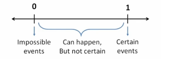

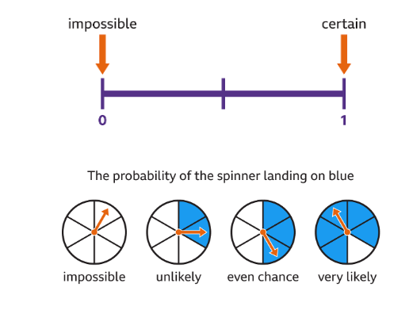

**Fórmula Geral:**

$probability=\frac{NumberOfFavorableOutcomes}{NumberOfPossibleEquallyLikelyOutcomes}$

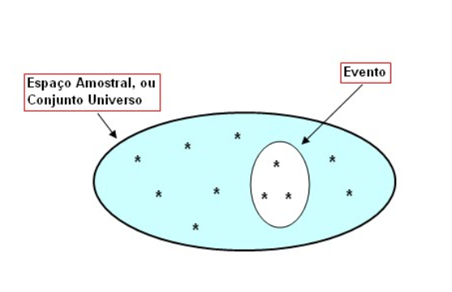

O conjunto de todos os resultados possíveis de um experimento é chamado de espaço amostral. Um evento é um subconjunto do **espaço amostral**. Quando constituído de constituído de apenas um evento, chama-se evento simples.

Eventos são subconjuntos do espaço amostral. Isso pode ser representado por diagramas de Veen

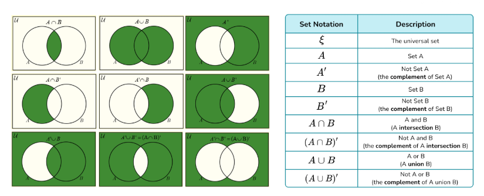

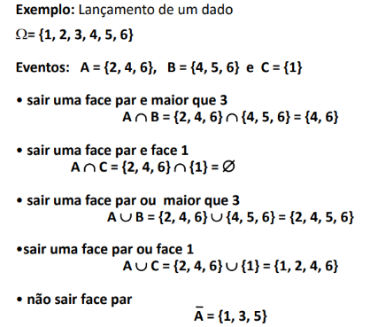

A **Estatística Inferencial** é construída sobre a base da **Teoria das Probabilidades** e tem sido extremamente bem-sucedida em guiar opiniões sobre conclusões extraídas de dados. No entanto, o conceito de probabilidade em si tem gerado muita controvérsia desde o seu início até os dias atuais. Vamos explorar diferentes formas de interpretar a probabilidade e discutir quando cada abordagem é mais adequada, a começar pela abordagem frequentista e subjetiva, e depois sobre a abordagem Bayesiana.

## ⚖️ Exemplo Teórico

Um experimento aleatório é uma ação ou processo que pode ser repetido várias vezes, sob as mesmas condições, e cujos resultados não podem ser previstos com certeza. Em outras palavras, é um procedimento no qual o resultado é incerto e determinado pelo acaso.

📝 Características de um Experimento Aleatório:

- Repetibilidade: Pode ser realizado várias vezes nas mesmas condições.
- Resultados Possíveis: O conjunto de todos os resultados possíveis é chamado de espaço amostral.
- Incerteza: Não é possível prever com exatidão qual será o resultado de uma única execução.
- Aleatoriedade: O resultado de cada execução é determinado pelo acaso.

Exemplos Clássicos de Experimentos Aleatórios: Lançamento de uma moeda:

- Espaço amostral: {Cara, Coroa}
- Não é possível prever qual lado cairá em um lançamento específico.

```python
# Espaço amostral para o lançamento de uma moeda:
espaco_amostral = ['cara', 'coroa']

# Número de resultados possíveis:
num_resultados_possiveis = len(espaco_amostral)

# Número de resultados favoráveis (sair cara):
num_resultados_favoraveis = 1  # 'cara' é o resultado desejado

# Probabilidade de sair cara:
probabilidade_cara = num_resultados_favoraveis / num_resultados_possiveis

print(f"A probabilidade de sair cara é: {probabilidade_cara}")
```

```
A probabilidade de sair cara é: 0.5
```

## 🔄 Abordagem Frequentista

Em teoria, os eventos simples são equiprováveis. No entanto, na maioria das situações práticas, os elementos do espaço amostral não são igualmente prováveis e, deste modo, a probabilidade dos eventos deve ser calculada utilizando-se da noção de freqüência relativa

A abordagem frequentista interpreta a probabilidade como a frequência relativa de um evento ao longo de um grande número de repetições. Quanto mais observações, mais precisa será a estimativa.

**Exemplo de Saúde:** Vamos simular um ensaio clínico com 1000 pacientes, onde a chance de complicações é de 20%:

```python
import numpy as np

# Definindo o número de pacientes na simulação
n_pacientes = 1000

# Gerando complicações com distribuição binomial (20% de chance)
# A função `np.random.binomial` gera um array binário (0 ou 1) de tamanho `n_pacientes`.
complicacoes = np.random.binomial(1, 0.20, n_pacientes)

# Calculando a probabilidade estimada de complicações
#A média dos valores resulta na probabilidade estimada de complicações.
probabilidade_real = np.mean(complicacoes)

print(f"Probabilidade estimada de complicações: {probabilidade_real * 100:.2f}%")
```

```
Probabilidade estimada de complicações: 23.50%
```

```python
import numpy as np

# Aumentando o número de pacientes para um bilhão
n_pacientes = 1000000000

# Simulando complicações novamente com probabilidade de 20%
complicacoes = np.random.binomial(1, 0.20, n_pacientes)
probabilidade_real = np.mean(complicacoes)
print(f"Probabilidade estimada de complicações: {probabilidade_real * 100:.2f}%")
```

```
Probabilidade estimada de complicações: 20.00%
```

## 🔄 À medida que a frequência aumenta, mais perto ficamos da probabilidade teórica

Na realidade, a freqüência relativa apenas converge para o valor da probabilidade do evento.

```python
from scipy.stats import binom

import pandas as pd

binom(1, 0.5).rvs()
```

```
1
```

```python
# Função que realiza n lançamentos de moeda e calcula a média de caras
def flip_n_coins(n):
    return binom(1, 0.5).rvs(n).mean()

# Executando a simulação para diferentes quantidades de lançamentos
flip_n_coins(10)
```

```
np.float64(0.6)
```

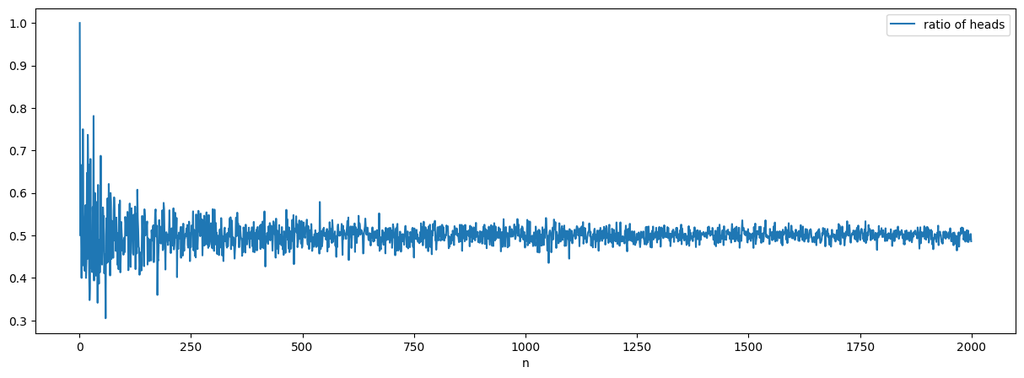

```python
#Gera um gráfico que mostra a proporção de caras conforme o número de lançamentos aumenta.
#A proporção tende a se estabilizar em 0,5 devido à simetria da moeda.

(
    pd.DataFrame(
        [(n, flip_n_coins(n)) for n in range(1, 2000)],
        columns=['n', 'ratio of heads']
    )
    .set_index('n')
    .plot(figsize=(15, 5))
);
```

## 🧩 Discussão Filosófica sobre a Abordagem Frequentista

A interpretação frequentista da probabilidade parte do princípio de que a probabilidade está associada à frequência de ocorrência de um evento ao longo de uma série de experimentos repetidos. Isso levanta questões filosóficas importantes sobre o que significa "probabilidade" e se ela realmente existe como uma propriedade intrínseca do evento ou se é apenas uma abstração matemática.

🔎 **Discussão:** Se choveu em Seattle em 62% dos últimos 100.000 dias, então a probabilidade de chover amanhã pode ser considerada 0,62. Esta é uma ideia natural, mas ainda assim irracional se tivermos mais informações relevantes sobre se choverá amanhã.

Por exemplo, se amanhã for 1º de agosto, um dia do ano em que raramente chove em Seattle, devemos considerar apenas a porcentagem do tempo em que choveu em 1º de agosto. Mas mesmo isso não é suficiente, pois a probabilidade de chuva no próximo 1º de agosto depende da umidade. (As chances são maiores na presença de alta umidade.) Então, devemos consultar apenas as ocorrências anteriores de 1º de agosto que tiveram a mesma umidade que a próxima ocorrência de 1º de agosto. Claro, a direção do vento também afeta a probabilidade... Você pode ver que nossa amostra de casos anteriores logo será reduzida ao conjunto vazio. De qualquer forma, a história meteorológica passada é enganosa se o clima estiver mudando.

## 🤔 Abordagem Subjetiva da Probabilidade

Para alguns propósitos, a probabilidade é melhor pensada como subjetiva. Perguntas como "Qual é a probabilidade de que a Sra. Garcia derrote o Sr. Smith em uma próxima eleição para o Congresso?" não se encaixam convenientemente nas abordagens de simetria ou frequência para probabilidade. Em vez disso, atribuir probabilidade 0,7 (digamos) a este evento parece refletir a opinião pessoal do orador --- talvez sua disposição de apostar de acordo com certas probabilidades. Tal abordagem para probabilidade, no entanto, parece perder o conteúdo objetivo da ideia de acaso; probabilidade se torna mera opinião.

Duas pessoas podem atribuir probabilidades diferentes ao resultado da eleição, mas não haveria critério para chamar uma de "certa" e a outra de "errada". Não podemos dizer que uma das duas pessoas está certa simplesmente porque ela atribuiu maior probabilidade ao resultado que realmente acontece. Afinal, você estaria certo em atribuir probabilidade 1/6 a tirar um seis com um dado justo, e seu amigo que atribui 2/3 a esse evento estaria errado. E você ainda está certo (e seu amigo ainda está errado) mesmo que o dado acabe mostrando um seis! A falta de critérios objetivos para julgar alegações sobre probabilidades na perspectiva subjetiva é uma característica pouco atraente para muitos acadêmicos.

## ⛪ Probabilidade não Dogmática

Como a maioria dos trabalhos na área, o presente texto adota a abordagem frequentista para probabilidade na maioria dos casos. Além disso, quase todas as probabilidades que encontraremos serão não dogmáticas, ou seja, nem zero nem um. Um evento com probabilidade 0 não tem chance de ocorrer; um evento de probabilidade 1 certamente ocorrerá. É difícil pensar em exemplos de interesse para estatística em que a probabilidade seja 0 ou 1. (Mesmo a probabilidade de o Sol nascer amanhã é menor que 1.)

O exemplo a seguir ilustra nossa atitude sobre probabilidades. Suponha que você queira saber como estará o tempo no próximo sábado porque está planejando um piquenique. Você liga o rádio e o meteorologista diz: "Há 10% de chance de chuva". Você decide fazer o piquenique ao ar livre e, vejam só, chove. Você fica furioso com a meteorologista. Mas ela estava errada? Não, ela não disse que não choveria, apenas que era improvável que chovesse. Ela estaria completamente errada apenas se dissesse que a probabilidade é 0 e subsequentemente chovesse. No entanto, se você acompanhasse as previsões do tempo dela por um longo período de tempo e descobrisse que choveu em 50% dos dias em que a meteorologista disse que a probabilidade era 0,10, você poderia dizer que suas avaliações de probabilidade estão erradas.

## 🗣️ Discussão: Erros Comuns e Falácias

### 🎰 A Falácia do Apostador

Acreditar que um evento futuro é influenciado por eventos passados, como pensar que após cinco resultados iguais, o próximo será diferente.

Na saúde, isso pode ocorrer ao supor que, após vários pacientes terem resposta positiva a um tratamento, o próximo terá menos chance de responder da mesma forma. Isso não faz sentido se os eventos são independentes.

### 🎂 **Paradoxo do Aniversário**

Qual a probabilidade de que, em uma sala com **23 pessoas**, pelo menos duas compartilhem a mesma data de aniversário? Este paradoxo é interessante porque a probabilidade é maior do que intuitivamente pensamos.

```python
import math

#Definimos uma função que calcula a probabilidade de nenhuma coincidência de aniversário em um grupo de `n` pessoas

def prob_compartilhar_aniversario(n):
    prob = 1.0
    for i in range(n):
        prob *= (365 - i) / 365
    return 1 - prob

n = 23
prob = prob_compartilhar_aniversario(n)
print(f'Probabilidade de pelo menos duas pessoas compartilharem aniversário em um grupo de {n}: {prob:.2%}')
```

```
Probabilidade de pelo menos duas pessoas compartilharem aniversário em um grupo de 23: 50.73%
```